# Risk Factor Analysis

## Outcome Variable

**Outcome Variable:** pers_wast

## Predictor Variables

**Intervention Variable:** mhtcm

**Adjustment Set:**

unadjusted

## Stratifying Variables

The analysis was stratified on these variable(s):

- agecat
- studyid
- country

## Data Summary

| agecat | studyid | country | mhtcm | pers_wast | n_cell | n |
| --- | --- | --- | --- | --- | --- | --- |
| 0-24 months | ki0047075b-MAL-ED | BANGLADESH | >=155 cm | 0 | 21 | 248 |
| 0-24 months | ki0047075b-MAL-ED | BANGLADESH | >=155 cm | 1 | 3 | 248 |
| 0-24 months | ki0047075b-MAL-ED | BANGLADESH | <151 cm | 0 | 154 | 248 |
| 0-24 months | ki0047075b-MAL-ED | BANGLADESH | <151 cm | 1 | 7 | 248 |
| 0-24 months | ki0047075b-MAL-ED | BANGLADESH | [151-155) cm | 0 | 60 | 248 |
| 0-24 months | ki0047075b-MAL-ED | BANGLADESH | [151-155) cm | 1 | 3 | 248 |
| 0-24 months | ki0047075b-MAL-ED | BRAZIL | >=155 cm | 0 | 124 | 217 |
| 0-24 months | ki0047075b-MAL-ED | BRAZIL | >=155 cm | 1 | 2 | 217 |
| 0-24 months | ki0047075b-MAL-ED | BRAZIL | <151 cm | 0 | 52 | 217 |
| 0-24 months | ki0047075b-MAL-ED | BRAZIL | <151 cm | 1 | 0 | 217 |
| 0-24 months | ki0047075b-MAL-ED | BRAZIL | [151-155) cm | 0 | 39 | 217 |
| 0-24 months | ki0047075b-MAL-ED | BRAZIL | [151-155) cm | 1 | 0 | 217 |
| 0-24 months | ki0047075b-MAL-ED | INDIA | >=155 cm | 0 | 53 | 240 |
| 0-24 months | ki0047075b-MAL-ED | INDIA | >=155 cm | 1 | 2 | 240 |
| 0-24 months | ki0047075b-MAL-ED | INDIA | <151 cm | 0 | 102 | 240 |
| 0-24 months | ki0047075b-MAL-ED | INDIA | <151 cm | 1 | 13 | 240 |
| 0-24 months | ki0047075b-MAL-ED | INDIA | [151-155) cm | 0 | 64 | 240 |
| 0-24 months | ki0047075b-MAL-ED | INDIA | [151-155) cm | 1 | 6 | 240 |
| 0-24 months | ki0047075b-MAL-ED | NEPAL | >=155 cm | 0 | 41 | 238 |
| 0-24 months | ki0047075b-MAL-ED | NEPAL | >=155 cm | 1 | 0 | 238 |
| 0-24 months | ki0047075b-MAL-ED | NEPAL | <151 cm | 0 | 131 | 238 |
| 0-24 months | ki0047075b-MAL-ED | NEPAL | <151 cm | 1 | 2 | 238 |
| 0-24 months | ki0047075b-MAL-ED | NEPAL | [151-155) cm | 0 | 62 | 238 |
| 0-24 months | ki0047075b-MAL-ED | NEPAL | [151-155) cm | 1 | 2 | 238 |
| 0-24 months | ki0047075b-MAL-ED | PERU | >=155 cm | 0 | 58 | 283 |
| 0-24 months | ki0047075b-MAL-ED | PERU | >=155 cm | 1 | 0 | 283 |
| 0-24 months | ki0047075b-MAL-ED | PERU | <151 cm | 0 | 165 | 283 |
| 0-24 months | ki0047075b-MAL-ED | PERU | <151 cm | 1 | 0 | 283 |
| 0-24 months | ki0047075b-MAL-ED | PERU | [151-155) cm | 0 | 59 | 283 |
| 0-24 months | ki0047075b-MAL-ED | PERU | [151-155) cm | 1 | 1 | 283 |

[output cut: 294 more lines]

The following strata were considered:

- agecat: 0-24 months, studyid: ki0047075b-MAL-ED, country: BANGLADESH
- agecat: 0-24 months, studyid: ki0047075b-MAL-ED, country: BRAZIL
- agecat: 0-24 months, studyid: ki0047075b-MAL-ED, country: INDIA
- agecat: 0-24 months, studyid: ki0047075b-MAL-ED, country: NEPAL
- agecat: 0-24 months, studyid: ki0047075b-MAL-ED, country: PERU
- agecat: 0-24 months, studyid: ki0047075b-MAL-ED, country: SOUTH AFRICA
- agecat: 0-24 months, studyid: ki0047075b-MAL-ED, country: TANZANIA, UNITED REPUBLIC OF
- agecat: 0-24 months, studyid: ki1000304b-SAS-CompFeed, country: INDIA
- agecat: 0-24 months, studyid: ki1000304b-SAS-FoodSuppl, country: INDIA
- agecat: 0-24 months, studyid: ki1017093-NIH-Birth, country: BANGLADESH
- agecat: 0-24 months, studyid: ki1017093b-PROVIDE, country: BANGLADESH
- agecat: 0-24 months, studyid: ki1017093c-NIH-Crypto, country: BANGLADESH
- agecat: 0-24 months, studyid: ki1066203-TanzaniaChild2, country: TANZANIA, UNITED REPUBLIC OF
- agecat: 0-24 months, studyid: ki1101329-Keneba, country: GAMBIA
- agecat: 0-24 months, studyid: ki1112895-Guatemala BSC, country: GUATEMALA
- agecat: 0-24 months, studyid: ki1112895-iLiNS-Zinc, country: BURKINA FASO
- agecat: 0-24 months, studyid: ki1119695-PROBIT, country: BELARUS
- agecat: 0-24 months, studyid: ki1126311-ZVITAMBO, country: ZIMBABWE
- agecat: 0-24 months, studyid: ki1135781-COHORTS, country: GUATEMALA
- agecat: 0-24 months, studyid: ki1135781-COHORTS, country: INDIA
- agecat: 0-24 months, studyid: ki1135781-COHORTS, country: PHILIPPINES
- agecat: 0-24 months, studyid: ki1148112-LCNI-5, country: MALAWI
- agecat: 0-24 months, studyid: kiGH5241-JiVitA-3, country: BANGLADESH
- agecat: 0-6 months, studyid: ki0047075b-MAL-ED, country: BANGLADESH
- agecat: 0-6 months, studyid: ki0047075b-MAL-ED, country: BRAZIL
- agecat: 0-6 months, studyid: ki0047075b-MAL-ED, country: INDIA
- agecat: 0-6 months, studyid: ki0047075b-MAL-ED, country: NEPAL
- agecat: 0-6 months, studyid: ki0047075b-MAL-ED, country: PERU
- agecat: 0-6 months, studyid: ki0047075b-MAL-ED, country: SOUTH AFRICA
- agecat: 0-6 months, studyid: ki0047075b-MAL-ED, country: TANZANIA, UNITED REPUBLIC OF
- agecat: 0-6 months, studyid: ki1017093b-PROVIDE, country: BANGLADESH
- agecat: 0-6 months, studyid: ki1066203-TanzaniaChild2, country: TANZANIA, UNITED REPUBLIC OF
- agecat: 0-6 months, studyid: ki1101329-Keneba, country: GAMBIA
- agecat: 6-24 months, studyid: ki0047075b-MAL-ED, country: BANGLADESH
- agecat: 6-24 months, studyid: ki0047075b-MAL-ED, country: BRAZIL
- agecat: 6-24 months, studyid: ki0047075b-MAL-ED, country: INDIA
- agecat: 6-24 months, studyid: ki0047075b-MAL-ED, country: NEPAL
- agecat: 6-24 months, studyid: ki0047075b-MAL-ED, country: PERU
- agecat: 6-24 months, studyid: ki0047075b-MAL-ED, country: SOUTH AFRICA
- agecat: 6-24 months, studyid: ki0047075b-MAL-ED, country: TANZANIA, UNITED REPUBLIC OF
- agecat: 6-24 months, studyid: ki1000304b-SAS-CompFeed, country: INDIA
- agecat: 6-24 months, studyid: ki1000304b-SAS-FoodSuppl, country: INDIA
- agecat: 6-24 months, studyid: ki1017093-NIH-Birth, country: BANGLADESH
- agecat: 6-24 months, studyid: ki1017093b-PROVIDE, country: BANGLADESH
- agecat: 6-24 months, studyid: ki1017093c-NIH-Crypto, country: BANGLADESH
- agecat: 6-24 months, studyid: ki1066203-TanzaniaChild2, country: TANZANIA, UNITED REPUBLIC OF
- agecat: 6-24 months, studyid: ki1101329-Keneba, country: GAMBIA
- agecat: 6-24 months, studyid: ki1112895-Guatemala BSC, country: GUATEMALA
- agecat: 6-24 months, studyid: ki1112895-iLiNS-Zinc, country: BURKINA FASO
- agecat: 6-24 months, studyid: ki1119695-PROBIT, country: BELARUS
- agecat: 6-24 months, studyid: ki1126311-ZVITAMBO, country: ZIMBABWE
- agecat: 6-24 months, studyid: ki1135781-COHORTS, country: GUATEMALA
- agecat: 6-24 months, studyid: ki1135781-COHORTS, country: PHILIPPINES
- agecat: 6-24 months, studyid: ki1148112-LCNI-5, country: MALAWI

### Dropped Strata

Some strata were dropped due to rare outcomes:

- agecat: 0-24 months, studyid: ki0047075b-MAL-ED, country: BANGLADESH
- agecat: 0-24 months, studyid: ki0047075b-MAL-ED, country: BRAZIL
- agecat: 0-24 months, studyid: ki0047075b-MAL-ED, country: INDIA
- agecat: 0-24 months, studyid: ki0047075b-MAL-ED, country: NEPAL
- agecat: 0-24 months, studyid: ki0047075b-MAL-ED, country: PERU
- agecat: 0-24 months, studyid: ki0047075b-MAL-ED, country: SOUTH AFRICA
- agecat: 0-24 months, studyid: ki0047075b-MAL-ED, country: TANZANIA, UNITED REPUBLIC OF
- agecat: 0-24 months, studyid: ki1017093c-NIH-Crypto, country: BANGLADESH
- agecat: 0-24 months, studyid: ki1112895-Guatemala BSC, country: GUATEMALA
- agecat: 0-24 months, studyid: ki1119695-PROBIT, country: BELARUS
- agecat: 0-24 months, studyid: ki1148112-LCNI-5, country: MALAWI
- agecat: 0-6 months, studyid: ki0047075b-MAL-ED, country: BANGLADESH
- agecat: 0-6 months, studyid: ki0047075b-MAL-ED, country: BRAZIL
- agecat: 0-6 months, studyid: ki0047075b-MAL-ED, country: INDIA
- agecat: 0-6 months, studyid: ki0047075b-MAL-ED, country: NEPAL
- agecat: 0-6 months, studyid: ki0047075b-MAL-ED, country: PERU
- agecat: 0-6 months, studyid: ki0047075b-MAL-ED, country: SOUTH AFRICA
- agecat: 0-6 months, studyid: ki0047075b-MAL-ED, country: TANZANIA, UNITED REPUBLIC OF
- agecat: 0-6 months, studyid: ki1017093b-PROVIDE, country: BANGLADESH
- agecat: 0-6 months, studyid: ki1101329-Keneba, country: GAMBIA
- agecat: 6-24 months, studyid: ki0047075b-MAL-ED, country: BANGLADESH
- agecat: 6-24 months, studyid: ki0047075b-MAL-ED, country: BRAZIL
- agecat: 6-24 months, studyid: ki0047075b-MAL-ED, country: INDIA
- agecat: 6-24 months, studyid: ki0047075b-MAL-ED, country: NEPAL
- agecat: 6-24 months, studyid: ki0047075b-MAL-ED, country: PERU
- agecat: 6-24 months, studyid: ki0047075b-MAL-ED, country: SOUTH AFRICA
- agecat: 6-24 months, studyid: ki0047075b-MAL-ED, country: TANZANIA, UNITED REPUBLIC OF
- agecat: 6-24 months, studyid: ki1112895-Guatemala BSC, country: GUATEMALA
- agecat: 6-24 months, studyid: ki1119695-PROBIT, country: BELARUS
- agecat: 6-24 months, studyid: ki1148112-LCNI-5, country: MALAWI

## Methods Detail

We’re interested in the causal parameters $E[Y_a]$ for all values of $a \in \mathcal{A}$. These parameters represent the mean outcome if, possibly contrary to fact, we intervened to set all units to have $A=a$. Under the randomization and positivity assumptions, these are identified by the statistical parameters $\psi_a=E_W[E_{Y|A,W}(Y|A=a,W)]$. In addition, we’re interested in the mean of $Y$, $E[Y]$ under no intervention (the observed mean). We will estimate these parameters by using SuperLearner to fit the relevant likelihood factors – $E_{Y|A,W}(Y|A=a,W)$ and $p(A=a|W)$, and then updating our likelihood fit using a joint TMLE.

For unadjusted analyses ($W=\{\}$), initial likelihoods were estimated using Lrnr_glm to estimate the simple $E(Y|A)$ and Lrnr_mean to estimate $p(A)$. For adjusted analyses, a small library containing Lrnr_glmnet, Lrnr_xgboost, and Lrnr_mean was used.

Having estimated these parameters, we will then use the delta method to estimate relative risks and attributable risks relative to a prespecified baseline level of $A$.

# Results Detail

## Results Plots

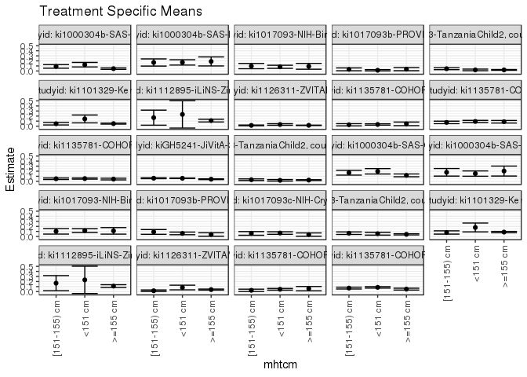

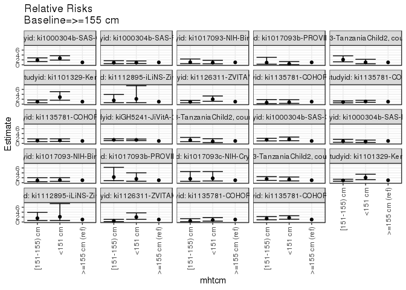

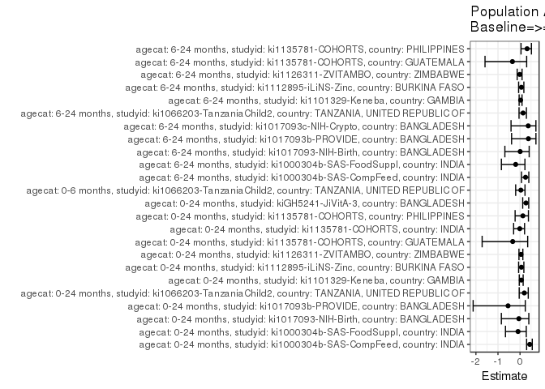

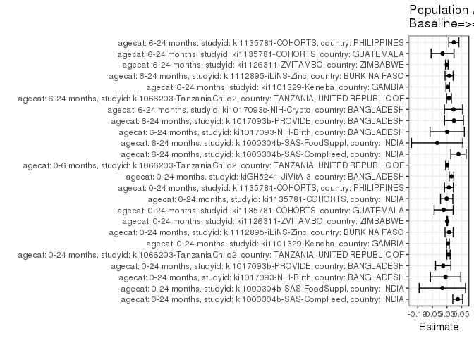

## Results Table

### Parameter: TSM

| agecat | studyid | country | intervention_level | baseline_level | estimate | ci_lower | ci_upper |
| --- | --- | --- | --- | --- | --- | --- | --- |
| 0-24 months | ki1000304b-SAS-CompFeed | INDIA | >=155 cm | NA | 0.0467290 | 0.0320565 | 0.0614015 |
| 0-24 months | ki1000304b-SAS-CompFeed | INDIA | <151 cm | NA | 0.1247059 | 0.0798920 | 0.1695198 |
| 0-24 months | ki1000304b-SAS-CompFeed | INDIA | [151-155) cm | NA | 0.0909091 | 0.0558662 | 0.1259520 |
| 0-24 months | ki1000304b-SAS-FoodSuppl | INDIA | >=155 cm | NA | 0.1891892 | 0.0998340 | 0.2785444 |
| 0-24 months | ki1000304b-SAS-FoodSuppl | INDIA | <151 cm | NA | 0.1701031 | 0.1171617 | 0.2230445 |
| 0-24 months | ki1000304b-SAS-FoodSuppl | INDIA | [151-155) cm | NA | 0.1682243 | 0.0972529 | 0.2391957 |
| 0-24 months | ki1017093-NIH-Birth | BANGLADESH | >=155 cm | NA | 0.0927835 | 0.0349925 | 0.1505745 |
| 0-24 months | ki1017093-NIH-Birth | BANGLADESH | <151 cm | NA | 0.0830671 | 0.0524639 | 0.1136702 |
| 0-24 months | ki1017093-NIH-Birth | BANGLADESH | [151-155) cm | NA | 0.0967742 | 0.0446880 | 0.1488603 |
| 0-24 months | ki1017093b-PROVIDE | BANGLADESH | >=155 cm | NA | 0.0362319 | 0.0050300 | 0.0674337 |
| 0-24 months | ki1017093b-PROVIDE | BANGLADESH | <151 cm | NA | 0.0143678 | 0.0018551 | 0.0268805 |
| 0-24 months | ki1017093b-PROVIDE | BANGLADESH | [151-155) cm | NA | 0.0326797 | 0.0044851 | 0.0608744 |
| 0-24 months | ki1066203-TanzaniaChild2 | TANZANIA, UNITED REPUBLIC OF | >=155 cm | NA | 0.0215613 | 0.0137972 | 0.0293255 |
| 0-24 months | ki1066203-TanzaniaChild2 | TANZANIA, UNITED REPUBLIC OF | <151 cm | NA | 0.0214724 | 0.0057337 | 0.0372111 |
| 0-24 months | ki1066203-TanzaniaChild2 | TANZANIA, UNITED REPUBLIC OF | [151-155) cm | NA | 0.0454545 | 0.0264562 | 0.0644529 |
| 0-24 months | ki1101329-Keneba | GAMBIA | >=155 cm | NA | 0.0503637 | 0.0402217 | 0.0605058 |
| 0-24 months | ki1101329-Keneba | GAMBIA | <151 cm | NA | 0.1428571 | 0.0646797 | 0.2210345 |
| 0-24 months | ki1101329-Keneba | GAMBIA | [151-155) cm | NA | 0.0484429 | 0.0236839 | 0.0732019 |
| 0-24 months | ki1112895-iLiNS-Zinc | BURKINA FASO | >=155 cm | NA | 0.1096818 | 0.0822983 | 0.1370653 |
| 0-24 months | ki1112895-iLiNS-Zinc | BURKINA FASO | <151 cm | NA | 0.2325581 | -0.0375474 | 0.5026637 |
| 0-24 months | ki1112895-iLiNS-Zinc | BURKINA FASO | [151-155) cm | NA | 0.1681416 | 0.0190819 | 0.3172013 |
| 0-24 months | ki1126311-ZVITAMBO | ZIMBABWE | >=155 cm | NA | 0.0167266 | 0.0135837 | 0.0198695 |
| 0-24 months | ki1126311-ZVITAMBO | ZIMBABWE | <151 cm | NA | 0.0330579 | 0.0171288 | 0.0489869 |
| 0-24 months | ki1126311-ZVITAMBO | ZIMBABWE | [151-155) cm | NA | 0.0152027 | 0.0082327 | 0.0221727 |
| 0-24 months | ki1135781-COHORTS | GUATEMALA | >=155 cm | NA | 0.0454545 | 0.0099029 | 0.0810062 |
| 0-24 months | ki1135781-COHORTS | GUATEMALA | <151 cm | NA | 0.0340237 | 0.0203508 | 0.0476966 |
| 0-24 months | ki1135781-COHORTS | GUATEMALA | [151-155) cm | NA | 0.0275229 | 0.0057950 | 0.0492509 |
| 0-24 months | ki1135781-COHORTS | INDIA | >=155 cm | NA | 0.0873181 | 0.0620821 | 0.1125541 |
| 0-24 months | ki1135781-COHORTS | INDIA | <151 cm | NA | 0.0929265 | 0.0717280 | 0.1141250 |
| 0-24 months | ki1135781-COHORTS | INDIA | [151-155) cm | NA | 0.0739030 | 0.0492542 | 0.0985518 |
| 0-24 months | ki1135781-COHORTS | PHILIPPINES | >=155 cm | NA | 0.0445969 | 0.0278384 | 0.0613555 |
| 0-24 months | ki1135781-COHORTS | PHILIPPINES | <151 cm | NA | 0.0541491 | 0.0423843 | 0.0659138 |
| 0-24 months | ki1135781-COHORTS | PHILIPPINES | [151-155) cm | NA | 0.0508685 | 0.0356964 | 0.0660406 |
| 0-24 months | kiGH5241-JiVitA-3 | BANGLADESH | >=155 cm | NA | 0.0417994 | 0.0335422 | 0.0500565 |
| 0-24 months | kiGH5241-JiVitA-3 | BANGLADESH | <151 cm | NA | 0.0597640 | 0.0542915 | 0.0652366 |
| 0-24 months | kiGH5241-JiVitA-3 | BANGLADESH | [151-155) cm | NA | 0.0611591 | 0.0526717 | 0.0696464 |
| 0-6 months | ki1066203-TanzaniaChild2 | TANZANIA, UNITED REPUBLIC OF | >=155 cm | NA | 0.0242188 | 0.0157951 | 0.0326424 |
| 0-6 months | ki1066203-TanzaniaChild2 | TANZANIA, UNITED REPUBLIC OF | <151 cm | NA | 0.0194805 | 0.0040419 | 0.0349191 |
| 0-6 months | ki1066203-TanzaniaChild2 | TANZANIA, UNITED REPUBLIC OF | [151-155) cm | NA | 0.0317460 | 0.0153788 | 0.0481133 |
| 6-24 months | ki1000304b-SAS-CompFeed | INDIA | >=155 cm | NA | 0.1176471 | 0.0897031 | 0.1455910 |
| 6-24 months | ki1000304b-SAS-CompFeed | INDIA | <151 cm | NA | 0.1978610 | 0.1446797 | 0.2510422 |
| 6-24 months | ki1000304b-SAS-CompFeed | INDIA | [151-155) cm | NA | 0.1698842 | 0.1221295 | 0.2176388 |
| 6-24 months | ki1000304b-SAS-FoodSuppl | INDIA | >=155 cm | NA | 0.2031250 | 0.1044153 | 0.3018347 |
| 6-24 months | ki1000304b-SAS-FoodSuppl | INDIA | <151 cm | NA | 0.1530055 | 0.1007729 | 0.2052380 |
| 6-24 months | ki1000304b-SAS-FoodSuppl | INDIA | [151-155) cm | NA | 0.1782178 | 0.1034756 | 0.2529601 |
| 6-24 months | ki1017093-NIH-Birth | BANGLADESH | >=155 cm | NA | 0.1111111 | 0.0461174 | 0.1761048 |
| 6-24 months | ki1017093-NIH-Birth | BANGLADESH | <151 cm | NA | 0.1161972 | 0.0788888 | 0.1535055 |
| 6-24 months | ki1017093-NIH-Birth | BANGLADESH | [151-155) cm | NA | 0.1016949 | 0.0471052 | 0.1562846 |
| 6-24 months | ki1017093b-PROVIDE | BANGLADESH | >=155 cm | NA | 0.0393701 | 0.0055192 | 0.0732209 |
| 6-24 months | ki1017093b-PROVIDE | BANGLADESH | <151 cm | NA | 0.0607903 | 0.0349492 | 0.0866314 |
| 6-24 months | ki1017093b-PROVIDE | BANGLADESH | [151-155) cm | NA | 0.0902778 | 0.0434316 | 0.1371239 |
| 6-24 months | ki1017093c-NIH-Crypto | BANGLADESH | >=155 cm | NA | 0.0378788 | 0.0052887 | 0.0704689 |
| 6-24 months | ki1017093c-NIH-Crypto | BANGLADESH | <151 cm | NA | 0.0676692 | 0.0430057 | 0.0923326 |
| 6-24 months | ki1017093c-NIH-Crypto | BANGLADESH | [151-155) cm | NA | 0.0602410 | 0.0240200 | 0.0964619 |
| 6-24 months | ki1066203-TanzaniaChild2 | TANZANIA, UNITED REPUBLIC OF | >=155 cm | NA | 0.0426136 | 0.0304276 | 0.0547997 |
| 6-24 months | ki1066203-TanzaniaChild2 | TANZANIA, UNITED REPUBLIC OF | <151 cm | NA | 0.0551181 | 0.0270446 | 0.0831916 |
| 6-24 months | ki1066203-TanzaniaChild2 | TANZANIA, UNITED REPUBLIC OF | [151-155) cm | NA | 0.0648649 | 0.0397623 | 0.0899675 |
| 6-24 months | ki1101329-Keneba | GAMBIA | >=155 cm | NA | 0.0865155 | 0.0730533 | 0.0999777 |
| 6-24 months | ki1101329-Keneba | GAMBIA | <151 cm | NA | 0.1780822 | 0.0902975 | 0.2658669 |
| 6-24 months | ki1101329-Keneba | GAMBIA | [151-155) cm | NA | 0.0792453 | 0.0467147 | 0.1117759 |
| 6-24 months | ki1112895-iLiNS-Zinc | BURKINA FASO | >=155 cm | NA | 0.1096818 | 0.0822983 | 0.1370653 |
| 6-24 months | ki1112895-iLiNS-Zinc | BURKINA FASO | <151 cm | NA | 0.2325581 | -0.0375474 | 0.5026637 |
| 6-24 months | ki1112895-iLiNS-Zinc | BURKINA FASO | [151-155) cm | NA | 0.1681416 | 0.0190819 | 0.3172013 |
| 6-24 months | ki1126311-ZVITAMBO | ZIMBABWE | >=155 cm | NA | 0.0407240 | 0.0308723 | 0.0505757 |
| 6-24 months | ki1126311-ZVITAMBO | ZIMBABWE | <151 cm | NA | 0.0814815 | 0.0353216 | 0.1276414 |
| 6-24 months | ki1126311-ZVITAMBO | ZIMBABWE | [151-155) cm | NA | 0.0176056 | 0.0023065 | 0.0329048 |
| 6-24 months | ki1135781-COHORTS | GUATEMALA | >=155 cm | NA | 0.0593220 | 0.0166763 | 0.1019677 |
| 6-24 months | ki1135781-COHORTS | GUATEMALA | <151 cm | NA | 0.0467446 | 0.0298306 | 0.0636585 |
| 6-24 months | ki1135781-COHORTS | GUATEMALA | [151-155) cm | NA | 0.0263158 | 0.0035424 | 0.0490892 |
| 6-24 months | ki1135781-COHORTS | PHILIPPINES | >=155 cm | NA | 0.0497238 | 0.0314370 | 0.0680105 |
| 6-24 months | ki1135781-COHORTS | PHILIPPINES | <151 cm | NA | 0.0844544 | 0.0695521 | 0.0993567 |
| 6-24 months | ki1135781-COHORTS | PHILIPPINES | [151-155) cm | NA | 0.0699208 | 0.0517632 | 0.0880785 |

### Parameter: E(Y)

| agecat | studyid | country | intervention_level | baseline_level | estimate | ci_lower | ci_upper |
| --- | --- | --- | --- | --- | --- | --- | --- |
| 0-24 months | ki1000304b-SAS-CompFeed | INDIA | NA | NA | 0.0835322 | 0.0594080 | 0.1076564 |
| 0-24 months | ki1000304b-SAS-FoodSuppl | INDIA | NA | NA | 0.1733333 | 0.1349698 | 0.2116969 |
| 0-24 months | ki1017093-NIH-Birth | BANGLADESH | NA | NA | 0.0880150 | 0.0639627 | 0.1120673 |
| 0-24 months | ki1017093b-PROVIDE | BANGLADESH | NA | NA | 0.0234742 | 0.0117259 | 0.0352225 |
| 0-24 months | ki1066203-TanzaniaChild2 | TANZANIA, UNITED REPUBLIC OF | NA | NA | 0.0267229 | 0.0198773 | 0.0335686 |
| 0-24 months | ki1101329-Keneba | GAMBIA | NA | NA | 0.0534138 | 0.0439136 | 0.0629141 |
| 0-24 months | ki1112895-iLiNS-Zinc | BURKINA FASO | NA | NA | 0.1169626 | 0.0922087 | 0.1417166 |
| 0-24 months | ki1126311-ZVITAMBO | ZIMBABWE | NA | NA | 0.0174830 | 0.0146224 | 0.0203435 |
| 0-24 months | ki1135781-COHORTS | GUATEMALA | NA | NA | 0.0341131 | 0.0230006 | 0.0452255 |
| 0-24 months | ki1135781-COHORTS | INDIA | NA | NA | 0.0862385 | 0.0726276 | 0.0998495 |
| 0-24 months | ki1135781-COHORTS | PHILIPPINES | NA | NA | 0.0512273 | 0.0430760 | 0.0593786 |
| 0-24 months | kiGH5241-JiVitA-3 | BANGLADESH | NA | NA | 0.0572397 | 0.0531274 | 0.0613520 |
| 0-6 months | ki1066203-TanzaniaChild2 | TANZANIA, UNITED REPUBLIC OF | NA | NA | 0.0251355 | 0.0183227 | 0.0319484 |
| 6-24 months | ki1000304b-SAS-CompFeed | INDIA | NA | NA | 0.1568981 | 0.1413796 | 0.1724166 |
| 6-24 months | ki1000304b-SAS-FoodSuppl | INDIA | NA | NA | 0.1695402 | 0.1300601 | 0.2090204 |
| 6-24 months | ki1017093-NIH-Birth | BANGLADESH | NA | NA | 0.1117886 | 0.0839169 | 0.1396604 |
| 6-24 months | ki1017093b-PROVIDE | BANGLADESH | NA | NA | 0.0633333 | 0.0438285 | 0.0828382 |
| 6-24 months | ki1017093c-NIH-Crypto | BANGLADESH | NA | NA | 0.0602583 | 0.0425793 | 0.0779372 |
| 6-24 months | ki1066203-TanzaniaChild2 | TANZANIA, UNITED REPUBLIC OF | NA | NA | 0.0494048 | 0.0390389 | 0.0597706 |
| 6-24 months | ki1101329-Keneba | GAMBIA | NA | NA | 0.0888779 | 0.0764467 | 0.1013090 |
| 6-24 months | ki1112895-iLiNS-Zinc | BURKINA FASO | NA | NA | 0.1169626 | 0.0922087 | 0.1417166 |
| 6-24 months | ki1126311-ZVITAMBO | ZIMBABWE | NA | NA | 0.0401831 | 0.0314999 | 0.0488664 |
| 6-24 months | ki1135781-COHORTS | GUATEMALA | NA | NA | 0.0441014 | 0.0307319 | 0.0574710 |
| 6-24 months | ki1135781-COHORTS | PHILIPPINES | NA | NA | 0.0731338 | 0.0631985 | 0.0830690 |

### Parameter: RR

| agecat | studyid | country | intervention_level | baseline_level | estimate | ci_lower | ci_upper |
| --- | --- | --- | --- | --- | --- | --- | --- |
| 0-24 months | ki1000304b-SAS-CompFeed | INDIA | >=155 cm | >=155 cm | 1.0000000 | 1.0000000 | 1.000000 |
| 0-24 months | ki1000304b-SAS-CompFeed | INDIA | <151 cm | >=155 cm | 2.6687058 | 1.9289938 | 3.692076 |
| 0-24 months | ki1000304b-SAS-CompFeed | INDIA | [151-155) cm | >=155 cm | 1.9454545 | 1.3376574 | 2.829419 |
| 0-24 months | ki1000304b-SAS-FoodSuppl | INDIA | >=155 cm | >=155 cm | 1.0000000 | 1.0000000 | 1.000000 |
| 0-24 months | ki1000304b-SAS-FoodSuppl | INDIA | <151 cm | >=155 cm | 0.8991163 | 0.5106997 | 1.582946 |
| 0-24 months | ki1000304b-SAS-FoodSuppl | INDIA | [151-155) cm | >=155 cm | 0.8891856 | 0.4720158 | 1.675052 |
| 0-24 months | ki1017093-NIH-Birth | BANGLADESH | >=155 cm | >=155 cm | 1.0000000 | 1.0000000 | 1.000000 |
| 0-24 months | ki1017093-NIH-Birth | BANGLADESH | <151 cm | >=155 cm | 0.8952787 | 0.4341874 | 1.846032 |
| 0-24 months | ki1017093-NIH-Birth | BANGLADESH | [151-155) cm | >=155 cm | 1.0430108 | 0.4579132 | 2.375716 |
| 0-24 months | ki1017093b-PROVIDE | BANGLADESH | >=155 cm | >=155 cm | 1.0000000 | 1.0000000 | 1.000000 |
| 0-24 months | ki1017093b-PROVIDE | BANGLADESH | <151 cm | >=155 cm | 0.3965517 | 0.1165172 | 1.349614 |
| 0-24 months | ki1017093b-PROVIDE | BANGLADESH | [151-155) cm | >=155 cm | 0.9019608 | 0.2665520 | 3.052062 |
| 0-24 months | ki1066203-TanzaniaChild2 | TANZANIA, UNITED REPUBLIC OF | >=155 cm | >=155 cm | 1.0000000 | 1.0000000 | 1.000000 |
| 0-24 months | ki1066203-TanzaniaChild2 | TANZANIA, UNITED REPUBLIC OF | <151 cm | >=155 cm | 0.9958748 | 0.4400867 | 2.253571 |
| 0-24 months | ki1066203-TanzaniaChild2 | TANZANIA, UNITED REPUBLIC OF | [151-155) cm | >=155 cm | 2.1081505 | 1.2142426 | 3.660140 |
| 0-24 months | ki1101329-Keneba | GAMBIA | >=155 cm | >=155 cm | 1.0000000 | 1.0000000 | 1.000000 |
| 0-24 months | ki1101329-Keneba | GAMBIA | <151 cm | >=155 cm | 2.8365079 | 1.5832134 | 5.081929 |
| 0-24 months | ki1101329-Keneba | GAMBIA | [151-155) cm | >=155 cm | 0.9618608 | 0.5553135 | 1.666043 |
| 0-24 months | ki1112895-iLiNS-Zinc | BURKINA FASO | >=155 cm | >=155 cm | 1.0000000 | 1.0000000 | 1.000000 |
| 0-24 months | ki1112895-iLiNS-Zinc | BURKINA FASO | <151 cm | >=155 cm | 2.1202986 | 0.5993847 | 7.500468 |
| 0-24 months | ki1112895-iLiNS-Zinc | BURKINA FASO | [151-155) cm | >=155 cm | 1.5329946 | 0.5990806 | 3.922799 |
| 0-24 months | ki1126311-ZVITAMBO | ZIMBABWE | >=155 cm | >=155 cm | 1.0000000 | 1.0000000 | 1.000000 |
| 0-24 months | ki1126311-ZVITAMBO | ZIMBABWE | <151 cm | >=155 cm | 1.9763652 | 1.1782927 | 3.314982 |
| 0-24 months | ki1126311-ZVITAMBO | ZIMBABWE | [151-155) cm | >=155 cm | 0.9088943 | 0.5537691 | 1.491757 |
| 0-24 months | ki1135781-COHORTS | GUATEMALA | >=155 cm | >=155 cm | 1.0000000 | 1.0000000 | 1.000000 |
| 0-24 months | ki1135781-COHORTS | GUATEMALA | <151 cm | >=155 cm | 0.7485207 | 0.3106798 | 1.803411 |
| 0-24 months | ki1135781-COHORTS | GUATEMALA | [151-155) cm | >=155 cm | 0.6055046 | 0.1992921 | 1.839690 |
| 0-24 months | ki1135781-COHORTS | INDIA | >=155 cm | >=155 cm | 1.0000000 | 1.0000000 | 1.000000 |
| 0-24 months | ki1135781-COHORTS | INDIA | <151 cm | >=155 cm | 1.0642296 | 0.7364284 | 1.537942 |
| 0-24 months | ki1135781-COHORTS | INDIA | [151-155) cm | >=155 cm | 0.8463653 | 0.5443670 | 1.315903 |
| 0-24 months | ki1135781-COHORTS | PHILIPPINES | >=155 cm | >=155 cm | 1.0000000 | 1.0000000 | 1.000000 |
| 0-24 months | ki1135781-COHORTS | PHILIPPINES | <151 cm | >=155 cm | 1.2141891 | 0.7866355 | 1.874127 |
| 0-24 months | ki1135781-COHORTS | PHILIPPINES | [151-155) cm | >=155 cm | 1.1406280 | 0.7059714 | 1.842896 |
| 0-24 months | kiGH5241-JiVitA-3 | BANGLADESH | >=155 cm | >=155 cm | 1.0000000 | 1.0000000 | 1.000000 |
| 0-24 months | kiGH5241-JiVitA-3 | BANGLADESH | <151 cm | >=155 cm | 1.4297832 | 1.1561182 | 1.768228 |
| 0-24 months | kiGH5241-JiVitA-3 | BANGLADESH | [151-155) cm | >=155 cm | 1.4631577 | 1.1426631 | 1.873545 |
| 0-6 months | ki1066203-TanzaniaChild2 | TANZANIA, UNITED REPUBLIC OF | >=155 cm | >=155 cm | 1.0000000 | 1.0000000 | 1.000000 |
| 0-6 months | ki1066203-TanzaniaChild2 | TANZANIA, UNITED REPUBLIC OF | <151 cm | >=155 cm | 0.8043569 | 0.3385130 | 1.911271 |
| 0-6 months | ki1066203-TanzaniaChild2 | TANZANIA, UNITED REPUBLIC OF | [151-155) cm | >=155 cm | 1.3108039 | 0.7037859 | 2.441377 |
| 6-24 months | ki1000304b-SAS-CompFeed | INDIA | >=155 cm | >=155 cm | 1.0000000 | 1.0000000 | 1.000000 |
| 6-24 months | ki1000304b-SAS-CompFeed | INDIA | <151 cm | >=155 cm | 1.6818182 | 1.0940212 | 2.585428 |
| 6-24 months | ki1000304b-SAS-CompFeed | INDIA | [151-155) cm | >=155 cm | 1.4440154 | 1.0022862 | 2.080424 |
| 6-24 months | ki1000304b-SAS-FoodSuppl | INDIA | >=155 cm | >=155 cm | 1.0000000 | 1.0000000 | 1.000000 |
| 6-24 months | ki1000304b-SAS-FoodSuppl | INDIA | <151 cm | >=155 cm | 0.7532577 | 0.4159352 | 1.364148 |
| 6-24 months | ki1000304b-SAS-FoodSuppl | INDIA | [151-155) cm | >=155 cm | 0.8773800 | 0.4617567 | 1.667102 |
| 6-24 months | ki1017093-NIH-Birth | BANGLADESH | >=155 cm | >=155 cm | 1.0000000 | 1.0000000 | 1.000000 |
| 6-24 months | ki1017093-NIH-Birth | BANGLADESH | <151 cm | >=155 cm | 1.0457746 | 0.5365946 | 2.038121 |
| 6-24 months | ki1017093-NIH-Birth | BANGLADESH | [151-155) cm | >=155 cm | 0.9152542 | 0.4137577 | 2.024591 |
| 6-24 months | ki1017093b-PROVIDE | BANGLADESH | >=155 cm | >=155 cm | 1.0000000 | 1.0000000 | 1.000000 |
| 6-24 months | ki1017093b-PROVIDE | BANGLADESH | <151 cm | >=155 cm | 1.5440727 | 0.5917156 | 4.029234 |
| 6-24 months | ki1017093b-PROVIDE | BANGLADESH | [151-155) cm | >=155 cm | 2.2930551 | 0.8399791 | 6.259801 |
| 6-24 months | ki1017093c-NIH-Crypto | BANGLADESH | >=155 cm | >=155 cm | 1.0000000 | 1.0000000 | 1.000000 |
| 6-24 months | ki1017093c-NIH-Crypto | BANGLADESH | <151 cm | >=155 cm | 1.7864656 | 0.7017669 | 4.547749 |
| 6-24 months | ki1017093c-NIH-Crypto | BANGLADESH | [151-155) cm | >=155 cm | 1.5903610 | 0.5567196 | 4.543127 |
| 6-24 months | ki1066203-TanzaniaChild2 | TANZANIA, UNITED REPUBLIC OF | >=155 cm | >=155 cm | 1.0000000 | 1.0000000 | 1.000000 |
| 6-24 months | ki1066203-TanzaniaChild2 | TANZANIA, UNITED REPUBLIC OF | <151 cm | >=155 cm | 1.2934382 | 0.7212158 | 2.319670 |
| 6-24 months | ki1066203-TanzaniaChild2 | TANZANIA, UNITED REPUBLIC OF | [151-155) cm | >=155 cm | 1.5221621 | 0.9407680 | 2.462857 |
| 6-24 months | ki1101329-Keneba | GAMBIA | >=155 cm | >=155 cm | 1.0000000 | 1.0000000 | 1.000000 |
| 6-24 months | ki1101329-Keneba | GAMBIA | <151 cm | >=155 cm | 2.0583845 | 1.2275253 | 3.451617 |
| 6-24 months | ki1101329-Keneba | GAMBIA | [151-155) cm | >=155 cm | 0.9159662 | 0.5905017 | 1.420816 |
| 6-24 months | ki1112895-iLiNS-Zinc | BURKINA FASO | >=155 cm | >=155 cm | 1.0000000 | 1.0000000 | 1.000000 |
| 6-24 months | ki1112895-iLiNS-Zinc | BURKINA FASO | <151 cm | >=155 cm | 2.1202986 | 0.5993847 | 7.500468 |
| 6-24 months | ki1112895-iLiNS-Zinc | BURKINA FASO | [151-155) cm | >=155 cm | 1.5329946 | 0.5990806 | 3.922799 |
| 6-24 months | ki1126311-ZVITAMBO | ZIMBABWE | >=155 cm | >=155 cm | 1.0000000 | 1.0000000 | 1.000000 |
| 6-24 months | ki1126311-ZVITAMBO | ZIMBABWE | <151 cm | >=155 cm | 2.0008230 | 1.0806476 | 3.704531 |
| 6-24 months | ki1126311-ZVITAMBO | ZIMBABWE | [151-155) cm | >=155 cm | 0.4323161 | 0.1754089 | 1.065495 |
| 6-24 months | ki1135781-COHORTS | GUATEMALA | >=155 cm | >=155 cm | 1.0000000 | 1.0000000 | 1.000000 |
| 6-24 months | ki1135781-COHORTS | GUATEMALA | <151 cm | >=155 cm | 0.7879800 | 0.3523628 | 1.762139 |
| 6-24 months | ki1135781-COHORTS | GUATEMALA | [151-155) cm | >=155 cm | 0.4436090 | 0.1440143 | 1.366454 |
| 6-24 months | ki1135781-COHORTS | PHILIPPINES | >=155 cm | >=155 cm | 1.0000000 | 1.0000000 | 1.000000 |
| 6-24 months | ki1135781-COHORTS | PHILIPPINES | <151 cm | >=155 cm | 1.6984720 | 1.1295519 | 2.553939 |
| 6-24 months | ki1135781-COHORTS | PHILIPPINES | [151-155) cm | >=155 cm | 1.4061859 | 0.8964335 | 2.205806 |

### Parameter: PAR

| agecat | studyid | country | intervention_level | baseline_level | estimate | ci_lower | ci_upper |
| --- | --- | --- | --- | --- | --- | --- | --- |
| 0-24 months | ki1000304b-SAS-CompFeed | INDIA | >=155 cm | NA | 0.0368032 | 0.0198664 | 0.0537401 |
| 0-24 months | ki1000304b-SAS-FoodSuppl | INDIA | >=155 cm | NA | -0.0158559 | -0.0952596 | 0.0635479 |
| 0-24 months | ki1017093-NIH-Birth | BANGLADESH | >=155 cm | NA | -0.0047685 | -0.0567779 | 0.0472409 |
| 0-24 months | ki1017093b-PROVIDE | BANGLADESH | >=155 cm | NA | -0.0127577 | -0.0390460 | 0.0135306 |
| 0-24 months | ki1066203-TanzaniaChild2 | TANZANIA, UNITED REPUBLIC OF | >=155 cm | NA | 0.0051616 | -0.0004171 | 0.0107402 |
| 0-24 months | ki1101329-Keneba | GAMBIA | >=155 cm | NA | 0.0030501 | -0.0016791 | 0.0077793 |
| 0-24 months | ki1112895-iLiNS-Zinc | BURKINA FASO | >=155 cm | NA | 0.0072809 | -0.0066286 | 0.0211903 |
| 0-24 months | ki1126311-ZVITAMBO | ZIMBABWE | >=155 cm | NA | 0.0007564 | -0.0007899 | 0.0023026 |
| 0-24 months | ki1135781-COHORTS | GUATEMALA | >=155 cm | NA | -0.0113415 | -0.0439327 | 0.0212497 |
| 0-24 months | ki1135781-COHORTS | INDIA | >=155 cm | NA | -0.0010796 | -0.0222314 | 0.0200723 |
| 0-24 months | ki1135781-COHORTS | PHILIPPINES | >=155 cm | NA | 0.0066304 | -0.0085616 | 0.0218224 |
| 0-24 months | kiGH5241-JiVitA-3 | BANGLADESH | >=155 cm | NA | 0.0154403 | 0.0075819 | 0.0232988 |
| 0-6 months | ki1066203-TanzaniaChild2 | TANZANIA, UNITED REPUBLIC OF | >=155 cm | NA | 0.0009168 | -0.0043601 | 0.0061936 |
| 6-24 months | ki1000304b-SAS-CompFeed | INDIA | >=155 cm | NA | 0.0392510 | 0.0130728 | 0.0654293 |
| 6-24 months | ki1000304b-SAS-FoodSuppl | INDIA | >=155 cm | NA | -0.0335848 | -0.1214394 | 0.0542698 |
| 6-24 months | ki1017093-NIH-Birth | BANGLADESH | >=155 cm | NA | 0.0006775 | -0.0581067 | 0.0594617 |
| 6-24 months | ki1017093b-PROVIDE | BANGLADESH | >=155 cm | NA | 0.0239632 | -0.0083049 | 0.0562314 |
| 6-24 months | ki1017093c-NIH-Crypto | BANGLADESH | >=155 cm | NA | 0.0223795 | -0.0088033 | 0.0535622 |
| 6-24 months | ki1066203-TanzaniaChild2 | TANZANIA, UNITED REPUBLIC OF | >=155 cm | NA | 0.0067911 | -0.0015314 | 0.0151137 |
| 6-24 months | ki1101329-Keneba | GAMBIA | >=155 cm | NA | 0.0023623 | -0.0034800 | 0.0082047 |
| 6-24 months | ki1112895-iLiNS-Zinc | BURKINA FASO | >=155 cm | NA | 0.0072809 | -0.0066286 | 0.0211903 |
| 6-24 months | ki1126311-ZVITAMBO | ZIMBABWE | >=155 cm | NA | -0.0005409 | -0.0049808 | 0.0038991 |
| 6-24 months | ki1135781-COHORTS | GUATEMALA | >=155 cm | NA | -0.0152206 | -0.0542615 | 0.0238203 |
| 6-24 months | ki1135781-COHORTS | PHILIPPINES | >=155 cm | NA | 0.0234100 | 0.0062199 | 0.0406001 |

### Parameter: PAF

| agecat | studyid | country | intervention_level | baseline_level | estimate | ci_lower | ci_upper |
| --- | --- | --- | --- | --- | --- | --- | --- |
| 0-24 months | ki1000304b-SAS-CompFeed | INDIA | >=155 cm | NA | 0.4405874 | 0.2984837 | 0.5539057 |
| 0-24 months | ki1000304b-SAS-FoodSuppl | INDIA | >=155 cm | NA | -0.0914761 | -0.6603265 | 0.2824784 |
| 0-24 months | ki1017093-NIH-Birth | BANGLADESH | >=155 cm | NA | -0.0541785 | -0.8462698 | 0.3980878 |
| 0-24 months | ki1017093b-PROVIDE | BANGLADESH | >=155 cm | NA | -0.5434783 | -2.1252205 | 0.2377097 |
| 0-24 months | ki1066203-TanzaniaChild2 | TANZANIA, UNITED REPUBLIC OF | >=155 cm | NA | 0.1931520 | -0.0377679 | 0.3726886 |
| 0-24 months | ki1101329-Keneba | GAMBIA | >=155 cm | NA | 0.0571032 | -0.0351526 | 0.1411370 |
| 0-24 months | ki1112895-iLiNS-Zinc | BURKINA FASO | >=155 cm | NA | 0.0622494 | -0.0641458 | 0.1736319 |
| 0-24 months | ki1126311-ZVITAMBO | ZIMBABWE | >=155 cm | NA | 0.0432627 | -0.0490968 | 0.1274912 |
| 0-24 months | ki1135781-COHORTS | GUATEMALA | >=155 cm | NA | -0.3324675 | -1.7178844 | 0.3467457 |
| 0-24 months | ki1135781-COHORTS | INDIA | >=155 cm | NA | -0.0125182 | -0.2900402 | 0.2053013 |
| 0-24 months | ki1135781-COHORTS | PHILIPPINES | >=155 cm | NA | 0.1294311 | -0.2229893 | 0.3802969 |
| 0-24 months | kiGH5241-JiVitA-3 | BANGLADESH | >=155 cm | NA | 0.2697487 | 0.1208592 | 0.3934226 |
| 0-6 months | ki1066203-TanzaniaChild2 | TANZANIA, UNITED REPUBLIC OF | >=155 cm | NA | 0.0364737 | -0.1978128 | 0.2249348 |
| 6-24 months | ki1000304b-SAS-CompFeed | INDIA | >=155 cm | NA | 0.2501690 | 0.0665540 | 0.3976658 |
| 6-24 months | ki1000304b-SAS-FoodSuppl | INDIA | >=155 cm | NA | -0.1980932 | -0.8447985 | 0.2219056 |
| 6-24 months | ki1017093-NIH-Birth | BANGLADESH | >=155 cm | NA | 0.0060606 | -0.6870427 | 0.4144099 |
| 6-24 months | ki1017093b-PROVIDE | BANGLADESH | >=155 cm | NA | 0.3783671 | -0.3831031 | 0.7206083 |
| 6-24 months | ki1017093c-NIH-Crypto | BANGLADESH | >=155 cm | NA | 0.3713923 | -0.4077958 | 0.7193147 |
| 6-24 months | ki1066203-TanzaniaChild2 | TANZANIA, UNITED REPUBLIC OF | >=155 cm | NA | 0.1374589 | -0.0458261 | 0.2886225 |
| 6-24 months | ki1101329-Keneba | GAMBIA | >=155 cm | NA | 0.0265796 | -0.0413336 | 0.0900638 |
| 6-24 months | ki1112895-iLiNS-Zinc | BURKINA FASO | >=155 cm | NA | 0.0622494 | -0.0641458 | 0.1736319 |
| 6-24 months | ki1126311-ZVITAMBO | ZIMBABWE | >=155 cm | NA | -0.0134601 | -0.1301617 | 0.0911907 |
| 6-24 months | ki1135781-COHORTS | GUATEMALA | >=155 cm | NA | -0.3451271 | -1.5871771 | 0.3006405 |
| 6-24 months | ki1135781-COHORTS | PHILIPPINES | >=155 cm | NA | 0.3200985 | 0.0444012 | 0.5162550 |